# Analysis of time series cointegration

Emmanuel ROCHE

14/03/2016

# Synopsis

In this report, we analyze the mean reversion of cointegrated time series. This analysis is based on the original study provided in **Ernest P.Chan - Algoritmic trading winning strategies and their rationales**.

# Data preprocessing

We retrieve the input datasets using the **quantmod** package. Here we are interested in the EWA and EWC Exchange Traded Funds (ETFs).

```r
library(quantmod)
options("getSymbols.warning4.0"=FALSE)

## Lets get first data  for EWA and EWC from yahoo finance and extract adjusted close prices
getSymbols(c("EWA","EWC"))
```

```
## [1] "EWA" "EWC"
```

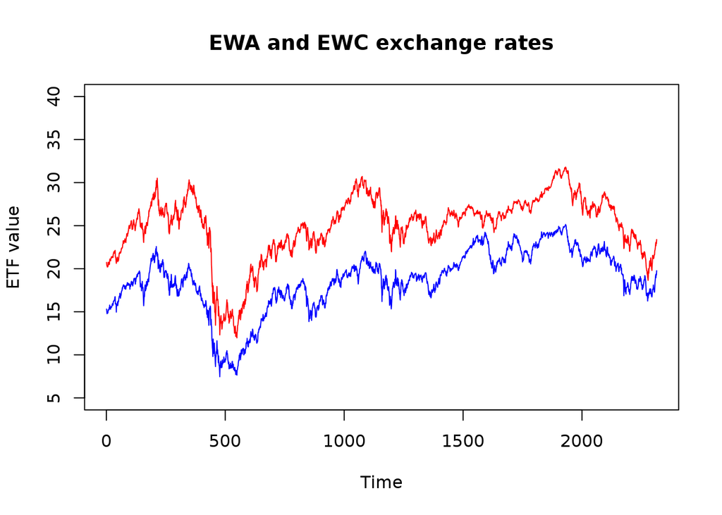

```r
ewaAdj <- unclass(EWA$EWA.Adjusted)
ewcAdj <- unclass(EWC$EWC.Adjusted)

# let's plot those close prices:
nob <- length(ewaAdj)
plot(1:nob, ewaAdj, type="l", col="blue", ylim=c(5, 40), xlab="Time", ylab="ETF value", main="EWA and EWC exchange rates")
lines(1:nob, ewcAdj, type="l", col="red")
```

We have here 2314 samples for EWA and 2314 samples for EWC. For sake of completion, let’s also display the candle chart for one for those symbols:

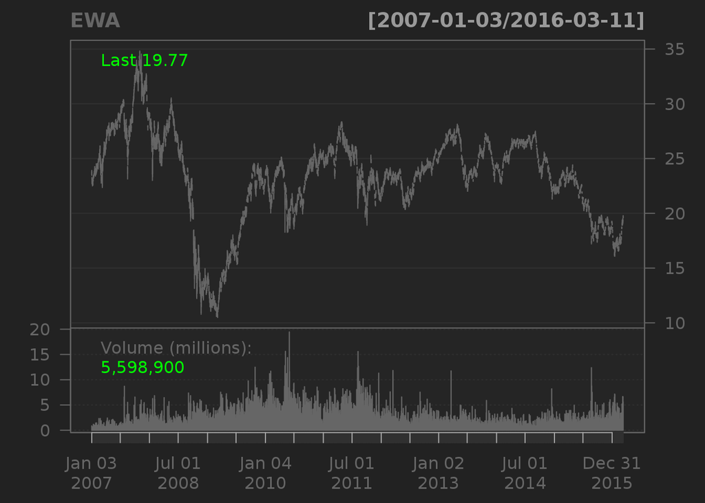

```r
candleChart(EWA)
```

According to the previous graph, the input data covers a period from 03/01/2007 to the current date.

# Results

To visually check the cointegration we can display a scatter plot of EWC against EWA:

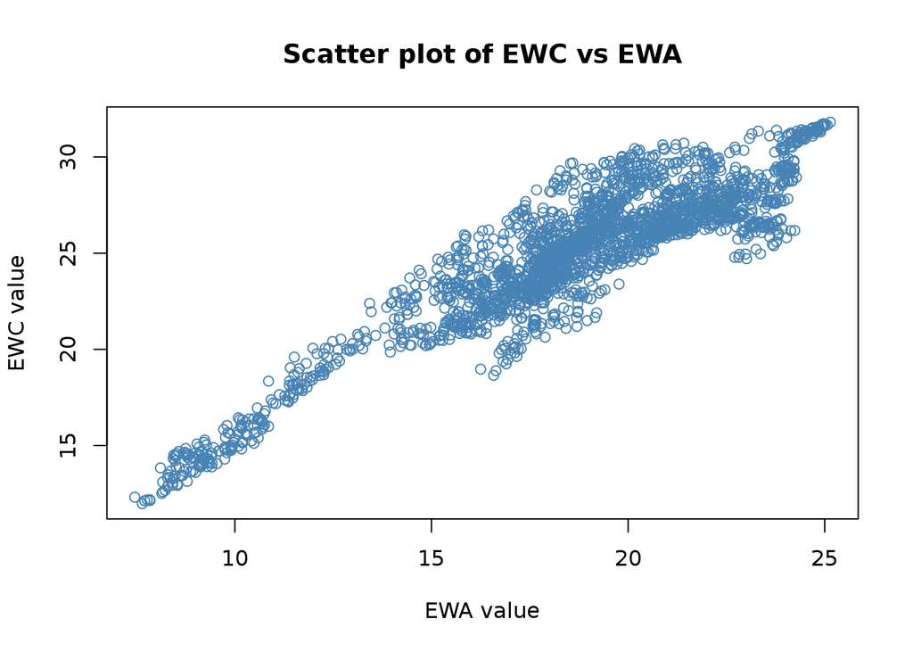

```r
plot(ewaAdj, ewcAdj,col="steelblue", xlab="EWA value", ylab="EWC value", main="Scatter plot of EWC vs EWA")
```

Now to perform the cointegration of the 2 series we first prepare an helper function, this implementation is inspired from [Deniz’s Notes](http://denizstij.blogspot.fr/2013/11/cointegration-tests-adf-and-johansen.html). This method will take as input the 2 series we are trying to co-integrate and return the statistic value, the p-value and the hedge ratio extracted from the regression.

Also note that we use the **fUnitRoots** package to compute the ADF test value.

```r
library(fUnitRoots)
```

```r
CADF <-function(aAdj, bAdj, type="nc") {
  lenA <- length(aAdj)
  lenB <- length(bAdj)

  # We expect both time series to have the same length:
  if(lenA != lenB)
  {
    stop(paste("Mismatch in input series lengths:",lenA,"!=",lenB))
  }

  regA <-lm(aAdj~bAdj+0)

  print(regA)
  regB <- lm(bAdj~aAdj+0)
  print(regB)

  coA <- adfTest(regA$residuals, type=type)
  coB <- adfTest(regB$residuals, type=type)

  # Lets choice most negative
  if (coA@test$statistic < coB@test$statistic){
    cat("\nSerie A is dependent on serie B")
    p <- coA@test$p.value
    s <- coA@test$statistic
    coeff <- regA$coefficients[[1]]
  }else {
    cat("\nSerie B is dependent on serie A")
    p <- coB@test$p.value
    s <- coB@test$statistic
    coeff <- regB$coefficients[[1]]
  }

  cat("\n p-value",p," statistics:",s," hedgeRatio:",coeff)
  return(c(s,p,coeff))
}
```

Now compute the cointegration of EWA anc EWC (note: not sure why we should use type=“nc” here and not type=“c” ?)

```r
res <- CADF(ewaAdj,ewcAdj, type="nc")
```

```
##
## Call:
## lm(formula = aAdj ~ bAdj + 0)
##
## Coefficients:
##   bAdj
## 0.7512
##
##
## Call:
## lm(formula = bAdj ~ aAdj + 0)
##
## Coefficients:
##  aAdj
## 1.322
```

```
##
## Serie B is dependent on serie A
##  p-value 0.01  statistics: -2.587024  hedgeRatio: 1.322135
```

```r
res
```

```
## Dickey-Fuller
##     -2.587024      0.010000      1.322135
```

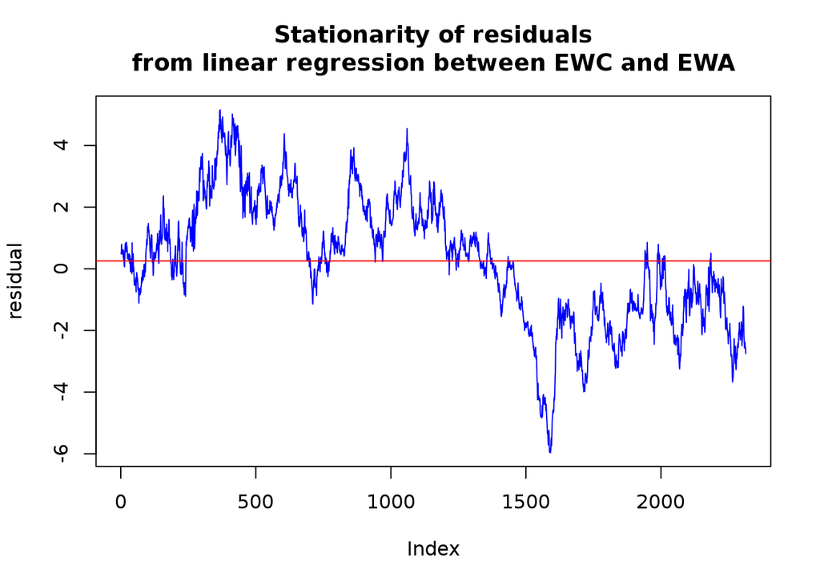

```r
residual <- ewcAdj - res[3]*ewaAdj
mval <- mean(residual)

plot(residual,type="l",col="blue", main="Stationarity of residuals\nfrom linear regression between EWC and EWA")
abline(h=mval,col="red")
```

We can confirm here that the first part of this plot is similar to what is provided in the original study.